# R Notebook

Clustering homework

You have been provided some customer data from a shopping centre. Do some exploratory analysis on the data. Comment on findings.

We are interested in creating a marketing campaign to target customers based on their spending score and annual income. Perform a k-means clustering to find if there are meaningful clusters in the data to target the customers.

Perform k-means clustering and chose a value of k.

Visualise the clustering for your chosen value of k.

Do you think the clustering seems a good fit for this data?

Comment on the attributes on one or two of the clusters (maybe even give them a label if you like - like in section 4.1 of the ‘Segmentation & clustering intro’ lesson).

```r
library(janitor)
library(fastDummies)
library(broom)
library(tidyverse)
library(factoextra)
```

```r
customers <- read_csv("data/mall_customers.csv") %>%
  clean_names()
customers
```

| customer_id | gender | age | annual_income_k | spending_score_1_100 |
| --- | --- | --- | --- | --- |
| 1 | Male | 19 | 15 | 39 |
| 2 | Male | 21 | 15 | 81 |
| 3 | Female | 20 | 16 | 6 |
| 4 | Female | 23 | 16 | 77 |
| 5 | Female | 31 | 17 | 40 |
| 6 | Female | 22 | 17 | 76 |
| 7 | Female | 35 | 18 | 6 |
| 8 | Female | 23 | 18 | 94 |
| 9 | Male | 64 | 19 | 3 |
| 10 | Female | 30 | 19 | 72 |

[output cut: 190 more lines]

```r
customers1 <- customers %>%
  select(annual_income_k, spending_score_1_100)

customers1
```

| annual_income_k | spending_score_1_100 |
| --- | --- |
| 15 | 39 |
| 15 | 81 |
| 16 | 6 |
| 16 | 77 |
| 17 | 40 |
| 17 | 76 |
| 18 | 6 |
| 18 | 94 |
| 19 | 3 |
| 19 | 72 |

[output cut: 190 more lines]

# The nstart parameter indicates that we want the algorithm to be executed 20 times.

# This number is not the number of iterations, it is like calling the function 20 times and then

# the execution with lower variance within the groups will be selected as the final result.

```r
clustering <- kmeans(customers1, centers = 5, nstart = 20)

clustering
```

```
K-means clustering with 5 clusters of sizes 35, 22, 39, 23, 81

Cluster means:
  annual_income_k spending_score_1_100
1        88.20000             17.11429
2        25.72727             79.36364
3        86.53846             82.12821
4        26.30435             20.91304
5        55.29630             49.51852

Clustering vector:
  [1] 4 2 4 2 4 2 4 2 4 2 4 2 4 2 4 2 4 2 4 2 4 2 4 2 4 2 4 2 4 2 4 2 4 2 4 2 4 2 4 2 4 2 4 5 4 2 5 5 5 5 5 5 5 5 5 5 5 5
 [59] 5 5 5 5 5 5 5 5 5 5 5 5 5 5 5 5 5 5 5 5 5 5 5 5 5 5 5 5 5 5 5 5 5 5 5 5 5 5 5 5 5 5 5 5 5 5 5 5 5 5 5 5 5 5 5 5 5 5
[117] 5 5 5 5 5 5 5 3 1 3 5 3 1 3 1 3 5 3 1 3 1 3 1 3 1 3 5 3 1 3 1 3 1 3 1 3 1 3 1 3 1 3 1 3 1 3 1 3 1 3 1 3 1 3 1 3 1 3
[175] 1 3 1 3 1 3 1 3 1 3 1 3 1 3 1 3 1 3 1 3 1 3 1 3 1 3

Within cluster sum of squares by cluster:
[1] 12511.143  3519.455 13444.051  5098.696  9875.111
 (between_SS / total_SS =  83.5 %)

Available components:

[1] "cluster"      "centers"      "totss"        "withinss"     "tot.withinss" "betweenss"    "size"
[8] "iter"         "ifault"
```

The kmeans() function outputs the results of the clustering. We can see the centroid vectors (cluster means), the group in which each observation was allocated (clustering vector) and a percentage (83.5%) that represents the compactness of the clustering, that is, how similar are the members within the same group.

Since we know that, we will use that percentage to help us decide our K value, that is, a number of groups that will have satisfactory variance and compactness.

The function below plots a chart showing the “within sum of squares” (withinss) by the number of groups (K value) chosen for several executions of the algorithm. The within sum of squares is a metric that shows how dissimilar are the members of a group., the greater is the sum, the greater is the dissimilarity within a group.

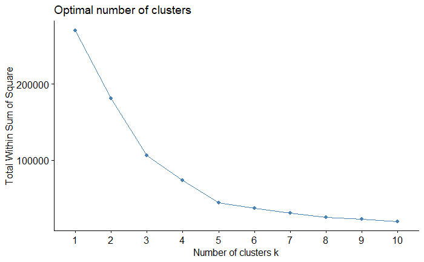

```r
options(scipen = 999)
fviz_nbclust(customers1,
             kmeans,
             method = "wss",
             nstart = 25)
```

K=3 to k=2 is a big difference in the sum of squares. That means that when it passes from 3 to 2 groups there is a reduction in the clustering compactness (by compactness, I mean the similarity within a group). Our goal, however, is not to achieve compactness of 100% — for that, we would just take each observation as a group. The main purpose is to find a fair number of groups that could explain satisfactorily a considerable part of the data.

Clustering Validation

|  | cluster | size | ave.sil.width |
| --- | --- | --- | --- |
| 1 | 1 | 35 | 0.50 |
| 2 | 2 | 22 | 0.60 |
| 3 | 3 | 39 | 0.51 |
| 4 | 4 | 23 | 0.51 |
| 5 | 5 | 81 | 0.60 |

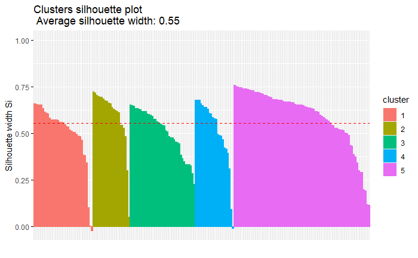

```r
library(cluster)
library(factoextra)

sil <- silhouette(clustering$cluster, dist(customers1))
fviz_silhouette(sil)
```

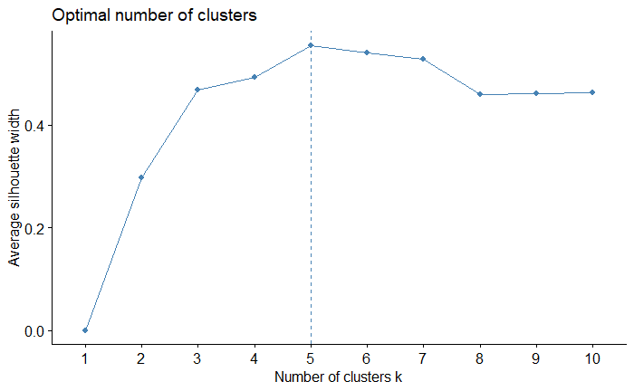

```r
fviz_nbclust(customers1, kmeans, method = "silhouette", nstart = 25)
```

Gap statistic

```
Clustering k = 1,2,..., K.max (= 10): .. done
Bootstrapping, b = 1,2,..., B (= 100)  [one "." per sample]:
.................................................. 50
.................................................. 100
```

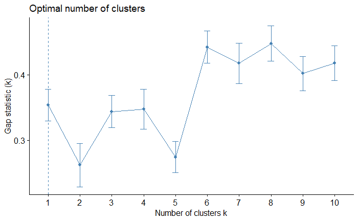

```r
fviz_nbclust(customers1, kmeans, method = "gap_stat") #would put nstart = 25 if had more computing power
```